# Poisson Distribution

# Introduction

This entire paragraph was taken over from the Introduction to Statistical Thought (written by Michael Lavine; published on June 24, 2010).

Another common type of observation occurs in the following situation.

- There is a domain of study, usually a block of space or time.
- Events arise seemingly at random in the domain.
- There is an underlying rate at which events arise.

Such observations are called Poisson after the 19th century French mathematician Siméon- Denis Poisson. The number of events in the domain of study helps us learn about the rate.

The rate at which events occur is often called λ; the number of events that occur in the domain of study is often called X; we write *X ∼ Poi(λ).* Important assumptions about Poisson observations are that two events cannot occur at exactly the same location in space or time, that the occurence of an event at location *$l_1$* does not influence whether an event occurs at any other location *$l_2$*, and the rate at which events arise does not vary over the domain of study.

# Generating Poisson Data

In the following simulation of a Poisson distribution, we are going to uniformly pick 200 points from a square of 5000x5000 points. The square can be divided into four quadrants, each having 2500x2500 points. Each of the four quadrants can be thought of as a separate domain of study and the rate with which points are picked from a given domain is $λ = \cfrac{200}{4} = 50$

The probability of picking exactly X points from the first quadrant follows a Poisson distribution *X ~ Poi(50)*.

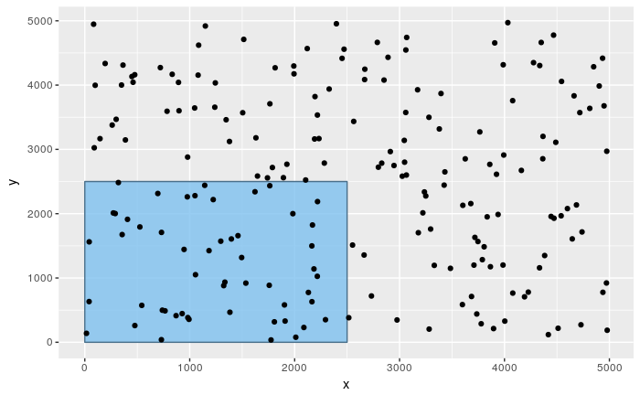

```r
library(tidyverse)
df <- data.frame(x = sample(5000, size=4*50, replace=FALSE), y = sample(5000, size=4*50, replace=FALSE))
q <- data.frame(x1=c(0), x2=c(2500), y1=c(0), y2=c(2500))
ggplot() +
  geom_rect(data=q, mapping=aes(xmin=x1, xmax=x2, ymin=y1, ymax=y2), fill="skyblue2", color="skyblue4", alpha=0.8) +
  geom_point(data=df, aes(x=x, y=y))
```

Let’s create a function *summarize.poisson.observations*, which takes the following parameters:

- lambda - a rate with which events occur in a given domain
- observations - a number of observations to be made

```r
summarize.poisson.observations <- function(lambda, observations) {
  results <- results <- 1:observations %>%
    map_int(function(x)
      as.integer(
        count(
          filter(data.frame(x = sample(5000, size=4*lambda, replace=FALSE), y = sample(5000, size=4*lambda, replace=FALSE)),
                 x <= 2500,
                 y <= 2500)
        )
      )
    )
  return(results)
}
```

Now we can use the function to generate 400 observations of X ∼ Poi(50):

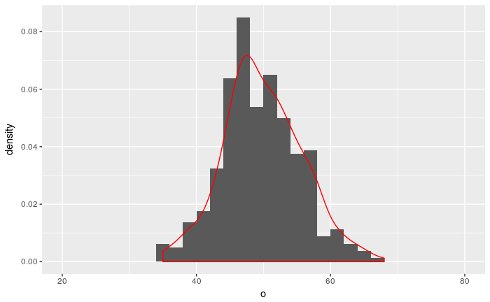

```r
summary <- summarize.poisson.observations(50, 400)
resulting.df <- data.frame(o <- summary) # ggplot only works with data frames
names(resulting.df) <- c("o")
#binPDF <- data.frame(x<-1:80, y<-dbinom(1:80, size=80, prob = 0.6))
#names(binPDF) <- c("flips", "prob")
ggplot(resulting.df) +
  geom_histogram(breaks=seq(20, 80, 2), aes(x=o, y=..density..), position="identity") +
  geom_density(aes(x=o, y = ..density..), colour="red") # + geom_line(data=binPDF, aes(flips, prob), colour="blue")
```

It turns out that R already contains a function which produces the same data as *summarize.poisson.observations*. The function is called *rpois* and it repeatedly performs a random draw from a Poisson distribution.

```r
drawsV1 <- summarize.poisson.observations(50, 400)
drawsV2 <- rpois(400, 50)
mean(drawsV1)
```

```
[1] 49.95
```

```r
mean(drawsV2)
```

```
[1] 50.175
```

```r
length(drawsV1)
```

```
[1] 400
```

```r
length(drawsV2)
```

```
[1] 400
```

# Probability Density

The probability of observing exactly 49 events in a given domain, given the rate is 50, can be estimated as

```r
mean(rpois(400, 50) == 49)
```

```
[1] 0.05
```

There is a special function in R which calculates the probability density - it is called *dpois*:

```r
dpois(49, 50)
```

```
[1] 0.05632501
```

# Cumulative Density

The probability of observing at most 45 events in a given domain, given the rate is 50, can be estimated as

```r
mean(rpois(400, 50) <= 45)
```

```
[1] 0.2975
```

There is a special function in R which calculates the cumulative density - it is called *ppois*:

```r
ppois(45, 50)
```

```
[1] 0.2668665
```

# Quantiles

Quantile works as an inverse of the cumulative density function, as illustrated below:

```r
qpois(ppois(45, 50), 50)
```

```
[1] 45
```

Visit [Basic Probability Distributions in R](https://rpubs.com/ggraham412/100906) for more information.

# Quantile-Quantile Plots

As described in the [Q-Q Plot Tutorial](https://intellinexus.wordpress.com/2010/11/29/creating-a-q-q-plot/), The quantile-quantile (q-q) plot is a graphical technique for determining if two data sets come from populations with a common distribution.

The following code compares observations stored in *x.sample* with those in *y.sample*:

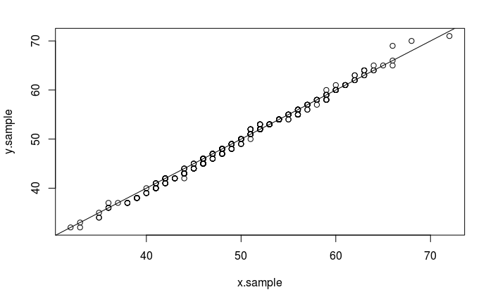

```r
x.sample <- rpois(400, 50)
y.sample <- rpois(400, 50)
qqplot(x.sample, y.sample)
abline(0,1)
```

The same test using *ggplot2*:

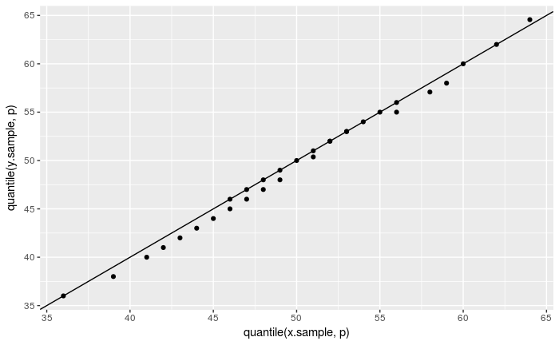

```r
nq <- 31
p <- (1 : nq) / nq - 0.5 / nq
ggplot() + geom_point(aes(x = quantile(x.sample, p), y = quantile(y.sample, p))) +
  geom_abline(intercept = 0, slope = 1)
```

Do the following to compare the *x.sample* with a Poisson distribution Poi(50):

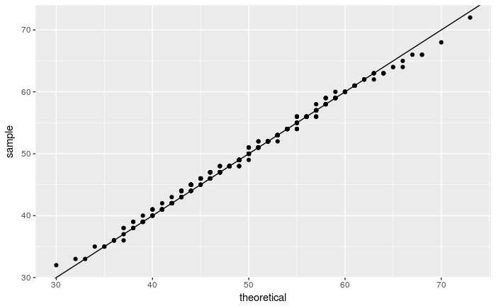

```r
xdf <-data.frame(x = x.sample)
ggplot(xdf, aes(sample = x)) +
  stat_qq(distribution = stats::qpois, dparams = list(lambda=50)) +
  geom_abline(intercept = 0, slope = 1)
```

# Further Reading

- [A quantile-quantile plot](http://ggplot2.tidyverse.org/reference/geom_qq.html)
- [QQ Plots and PP Plots](http://homepage.divms.uiowa.edu/~luke/classes/STAT4580/qqpp.html)
- [Q-Q Plot Tutorial](https://intellinexus.wordpress.com/2010/11/29/creating-a-q-q-plot/)